# Reproducible Research: Peer Assessment 1

Alessandra Coletti

10 luglio 2016

## Loading and preprocessing the data

### Load the data

```r
setwd("C:/Users/IBM_ADMIN/Desktop/personale/Coursera/Data Science Specialization/5 - Reproducible Research/Week 2")
activity <- read.csv("activity.csv")
```

#### See what our data frame is all about

```r
names(activity)
```

```
## [1] "steps"    "date"     "interval"
```

```r
str(activity)
```

```
## 'data.frame':    17568 obs. of  3 variables:
##  $ steps   : int  NA NA NA NA NA NA NA NA NA NA ...
##  $ date    : Factor w/ 61 levels "2012-10-01","2012-10-02",..: 1 1 1 1 1 1 1 1 1 1 ...
##  $ interval: int  0 5 10 15 20 25 30 35 40 45 ...
```

```r
head(activity,10)
```

```
##    steps       date interval
## 1     NA 2012-10-01        0
## 2     NA 2012-10-01        5
## 3     NA 2012-10-01       10
## 4     NA 2012-10-01       15
## 5     NA 2012-10-01       20
## 6     NA 2012-10-01       25
## 7     NA 2012-10-01       30
## 8     NA 2012-10-01       35
## 9     NA 2012-10-01       40
## 10    NA 2012-10-01       45
```

### Process/transform the data into a format suitable for your analysis

###### subset data frame to values without NA for later use

```r
without_na <- activity[complete.cases(activity),]
```

## What is mean total number of steps taken per day?

### Make a histogram of the total number of steps taken each day

##### total number of steps taken per day

```r
total <- aggregate(steps ~ date, without_na, sum)
```

##### add descriptive variable names

```r
names(total)[2] <- "sum_steps"
```

##### check out new data frame

```r
head(total, 5)
```

```
##         date sum_steps
## 1 2012-10-02       126
## 2 2012-10-03     11352
## 3 2012-10-04     12116
## 4 2012-10-05     13294
## 5 2012-10-06     15420
```

##### plot histogram

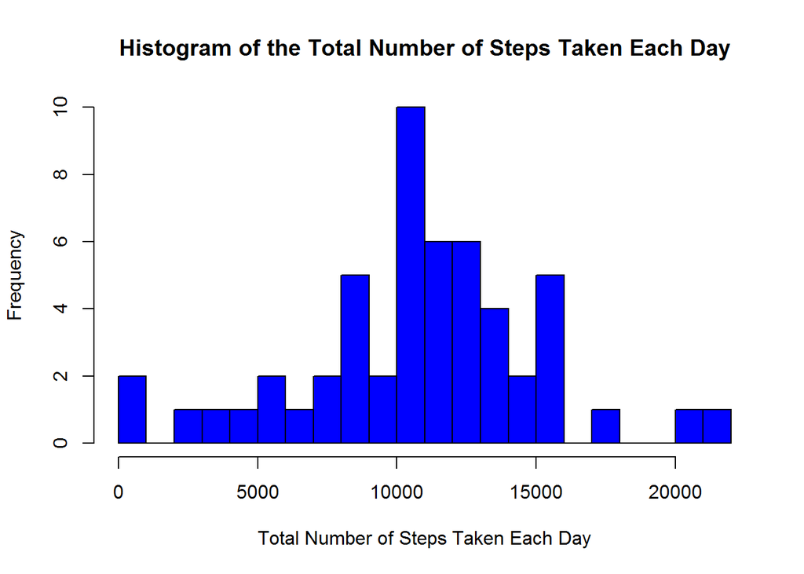

```r
hist(
        total$sum_steps,
        col = "blue",
        main = "Histogram of the Total Number of Steps Taken Each Day",
        xlab = "Total Number of Steps Taken Each Day",
        breaks = 20
)
```

### Calculate and report the mean and median total number of steps taken per day

##### mean

```r
mean(total$sum_steps)
```

```
## [1] 10766.19
```

##### median

```r
median(total$sum_steps)
```

```
## [1] 10765
```

## What is the average daily activity pattern?

### Make a time series plot of the 5-minute interval (x-axis) and the average number of steps taken, averaged across all days (y-axis)

##### the average number of steps taken, averaged across all days for each 5-minute interval

```r
interval <- aggregate(steps ~ interval, without_na, mean)
```

##### add descriptive variable names

```r
names(interval)[2] <- "mean_steps"
```

##### check out new data frame

```r
head(interval, 5)
```

```
##   interval mean_steps
## 1        0  1.7169811
## 2        5  0.3396226
## 3       10  0.1320755
## 4       15  0.1509434
## 5       20  0.0754717
```

##### format plot margins to accommodate long text labels

```r
par(mai = c(1.2,1.5,1,1))
```

##### plot time series

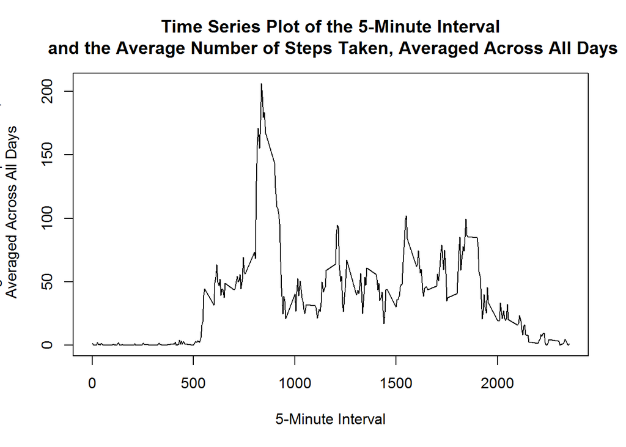

```r
plot(
        x = interval$interval,
        y = interval$mean_steps,
        type = "l",
        main = "Time Series Plot of the 5-Minute Interval\n and the Average Number of Steps Taken, Averaged Across All Days",
        xlab = "5-Minute Interval",
        ylab = "Average Number of Steps Taken,\n Averaged Across All Days"
)
```

### Which 5-minute interval, on average across all the days in the dataset, contains the maximum number of steps?

```r
interval[interval$mean_steps==max(interval$mean_steps),]
```

```
##     interval mean_steps
## 104      835   206.1698
```

## Imputing missing values

### Calculate and report the total number of missing values in the dataset

```r
nrow(activity[is.na(activity$steps),])
```

```
## [1] 2304
```

### Devise a strategy for filling in all of the missing values in the dataset

#### I will use the mean for the 5-minute interval to populate NA values for a given interval

### Create a new dataset that is equal to the original dataset but with the missing data filled in

##### merge original activity data frame with interval data frame

```r
newactivity <- merge(activity, interval, by = 'interval', all.y = F)
```

##### merge NA values with averages rounding up for integers

```r
newactivity$steps[is.na(newactivity$steps)] <- as.integer(
        round(newactivity$mean_steps[is.na(newactivity$steps)]))
```

##### drop and reorder columns to match original activity data frame

```r
keeps <- names(activity)
newactivity <- newactivity[keeps]
```

### Make a histogram of the total number of steps taken each day and calculate and report the mean and median total number of steps taken per day

##### total number of steps taken per day

```r
newtotal <- aggregate(steps ~ date, newactivity, sum)
```

##### add descriptive variable names

```r
names(newtotal)[2] <- "sum_steps"
```

##### check out new data frame

```r
head(newtotal, 5)
```

```
##         date sum_steps
## 1 2012-10-01     10762
## 2 2012-10-02       126
## 3 2012-10-03     11352
## 4 2012-10-04     12116
## 5 2012-10-05     13294
```

##### plot histogram

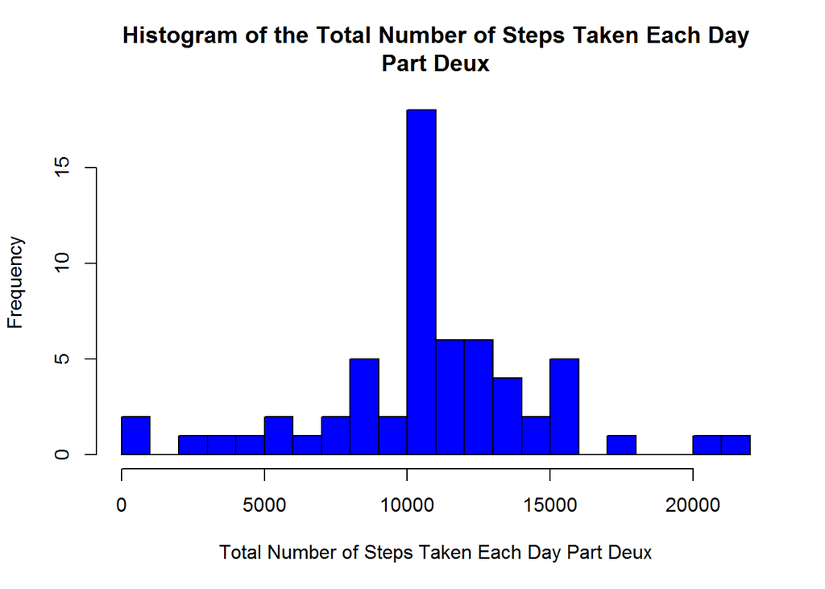

```r
hist(
        newtotal$sum_steps,
        col = "blue",
        main = "Histogram of the Total Number of Steps Taken Each Day\nPart Deux",
        xlab = "Total Number of Steps Taken Each Day Part Deux",
        breaks = 20
)
```

##### mean

```r
mean(newtotal$sum_steps)
```

```
## [1] 10765.64
```

##### median

```r
median(newtotal$sum_steps)
```

```
## [1] 10762
```

### Do these values differ from the estimates from the first part of the assignment?

#### They do differ, but ever so slightly:

#### mean(total) = 10766.19, while mean(newtotal) = 10765.64 - rounding produces the same value

#### median(total) = 10765, while median(newtotal) = 10762 - 3 step difference

### What is the impact of imputing missing data on the estimates of the total daily number of steps?

#### This seems to highly depend on how you impute the missing data. Since I used the average for a given interval, there was practically no difference because we basically pulled the averages closer to the inserted average value.

## Are there differences in activity patterns between weekdays and weekends?

### Create a new factor variable in the dataset with two levels - “weekday” and “weekend” indicating whether a given date is a weekday or weekend day

##### create new data frame

```r
newnewactivity <- newactivity
```

##### set up logical/test vector

```r
weekend <- weekdays(as.Date(newnewactivity$date)) %in% c("sabato", "domenica")
```

##### Fill in weekday column

```r
newnewactivity$daytype <- "weekday"
```

##### replace “weekday” with “weekend” where day == Sat/Sun

```r
newnewactivity$daytype[weekend == TRUE] <- "weekend"
```

##### convert new character column to factor

```r
newnewactivity$daytype <- as.factor(newnewactivity$daytype)
```

##### Check out new data frame

```r
str(newnewactivity)
```

```
## 'data.frame':    17568 obs. of  4 variables:
##  $ steps   : int  2 0 0 0 0 0 0 0 0 0 ...
##  $ date    : Factor w/ 61 levels "2012-10-01","2012-10-02",..: 1 54 28 37 55 46 20 47 38 56 ...
##  $ interval: int  0 0 0 0 0 0 0 0 0 0 ...
##  $ daytype : Factor w/ 2 levels "weekday","weekend": 1 1 2 1 2 1 2 1 1 2 ...
```

```r
head(newnewactivity, 5)
```

```
##   steps       date interval daytype
## 1     2 2012-10-01        0 weekday
## 2     0 2012-11-23        0 weekday
## 3     0 2012-10-28        0 weekend
## 4     0 2012-11-06        0 weekday
## 5     0 2012-11-24        0 weekend
```

##### double check

```r
weekdays(as.Date(newnewactivity$date[3]))
```

```
## [1] "domenica"
```

### Make a panel plot containing a time series plot of the 5-minute interval (x-axis) and the average number of steps taken, averaged across all weekday days or weekend days (y-axis)

##### the average number of steps taken, averaged across all days for each 5-minute interval

```r
newinterval <- aggregate(steps ~ interval + daytype, newnewactivity, mean)
```

##### add descriptive variable names

```r
names(newinterval)[3] <- "mean_steps"
```

##### check out new data frame

```r
head(newinterval, 5)
```

```
##   interval daytype mean_steps
## 1        0 weekday 2.28888889
## 2        5 weekday 0.40000000
## 3       10 weekday 0.15555556
## 4       15 weekday 0.17777778
## 5       20 weekday 0.08888889
```

##### plot time series

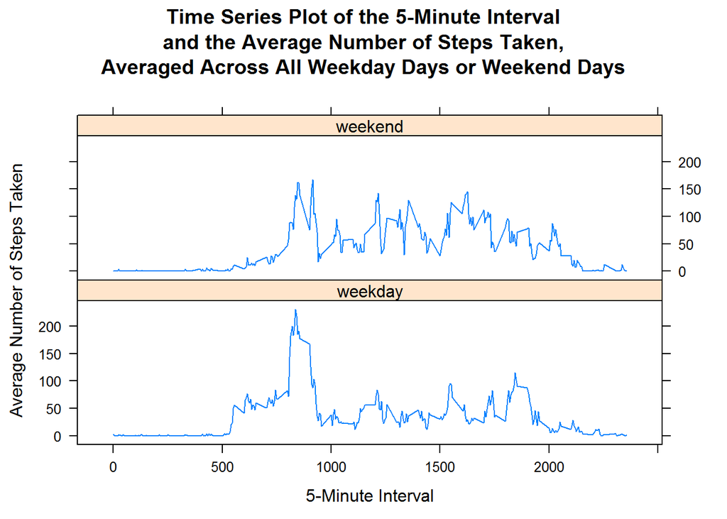

```r
library(lattice)
xyplot(
        mean_steps ~ interval | daytype,
        newinterval,
        type = "l",
        layout = c(1,2),
        main = "Time Series Plot of the 5-Minute Interval\nand the Average Number of Steps Taken,\nAveraged Across All Weekday Days or Weekend Days",
        xlab = "5-Minute Interval",
        ylab = "Average Number of Steps Taken"
)
```